# StrokeData_Visualizations

## Stroke Dataset - Data Visualization

In this notebook we will be exploring the dataset using visualizations.

Loading in libraries

```python
import pandas as pd
import matplotlib.pyplot as plt
import numpy as np
from IPython.display import display
```

Loading in dataset

```python
data = pd.read_csv('healthcare-dataset-stroke-data.csv')
```

Summary statistics of all variables in the dataset.

```python
data.describe(include="all")
```

|  | id | gender | age | hypertension | heart_disease | ever_married | work_type | Residence_type | avg_glucose_level | bmi | smoking_status | stroke |
| --- | --- | --- | --- | --- | --- | --- | --- | --- | --- | --- | --- | --- |
| count | 5110.000000 | 5110 | 5110.000000 | 5110.000000 | 5110.000000 | 5110 | 5110 | 5110 | 5110.000000 | 4909.000000 | 5110 | 5110.000000 |
| unique | NaN | 3 | NaN | NaN | NaN | 2 | 5 | 2 | NaN | NaN | 4 | NaN |
| top | NaN | Female | NaN | NaN | NaN | Yes | Private | Urban | NaN | NaN | never smoked | NaN |
| freq | NaN | 2994 | NaN | NaN | NaN | 3353 | 2925 | 2596 | NaN | NaN | 1892 | NaN |
| mean | 36517.829354 | NaN | 43.226614 | 0.097456 | 0.054012 | NaN | NaN | NaN | 106.147677 | 28.893237 | NaN | 0.048728 |
| std | 21161.721625 | NaN | 22.612647 | 0.296607 | 0.226063 | NaN | NaN | NaN | 45.283560 | 7.854067 | NaN | 0.215320 |
| min | 67.000000 | NaN | 0.080000 | 0.000000 | 0.000000 | NaN | NaN | NaN | 55.120000 | 10.300000 | NaN | 0.000000 |
| 25% | 17741.250000 | NaN | 25.000000 | 0.000000 | 0.000000 | NaN | NaN | NaN | 77.245000 | 23.500000 | NaN | 0.000000 |
| 50% | 36932.000000 | NaN | 45.000000 | 0.000000 | 0.000000 | NaN | NaN | NaN | 91.885000 | 28.100000 | NaN | 0.000000 |
| 75% | 54682.000000 | NaN | 61.000000 | 0.000000 | 0.000000 | NaN | NaN | NaN | 114.090000 | 33.100000 | NaN | 0.000000 |
| max | 72940.000000 | NaN | 82.000000 | 1.000000 | 1.000000 | NaN | NaN | NaN | 271.740000 | 97.600000 | NaN | 1.000000 |

```python
data.head()
```

|  | id | gender | age | hypertension | heart_disease | ever_married | work_type | Residence_type | avg_glucose_level | bmi | smoking_status | stroke |
| --- | --- | --- | --- | --- | --- | --- | --- | --- | --- | --- | --- | --- |
| 0 | 9046 | Male | 67.0 | 0 | 1 | Yes | Private | Urban | 228.69 | 36.6 | formerly smoked | 1 |
| 1 | 51676 | Female | 61.0 | 0 | 0 | Yes | Self-employed | Rural | 202.21 | NaN | never smoked | 1 |
| 2 | 31112 | Male | 80.0 | 0 | 1 | Yes | Private | Rural | 105.92 | 32.5 | never smoked | 1 |
| 3 | 60182 | Female | 49.0 | 0 | 0 | Yes | Private | Urban | 171.23 | 34.4 | smokes | 1 |
| 4 | 1665 | Female | 79.0 | 1 | 0 | Yes | Self-employed | Rural | 174.12 | 24.0 | never smoked | 1 |

```python
data.shape
```

```
(5110, 12)
```

Seeing if there are any null values in the dataset for any variable.

```python
data.isnull().sum()
```

```
id                     0
gender                 0
age                    0
hypertension           0
heart_disease          0
ever_married           0
work_type              0
Residence_type         0
avg_glucose_level      0
bmi                  201
smoking_status         0
stroke                 0
dtype: int64
```

Only the variable 'bmi' has null values. Replacing these missing values with the mean value of all the bmi data.

```python
data.bmi.fillna(data.bmi.mean(),axis = 0, inplace = True)
```

Confirming there are no more missing or null values in dataset.

```python
data.isnull().sum()
```

```
id                   0
gender               0
age                  0
hypertension         0
heart_disease        0
ever_married         0
work_type            0
Residence_type       0
avg_glucose_level    0
bmi                  0
smoking_status       0
stroke               0
dtype: int64
```

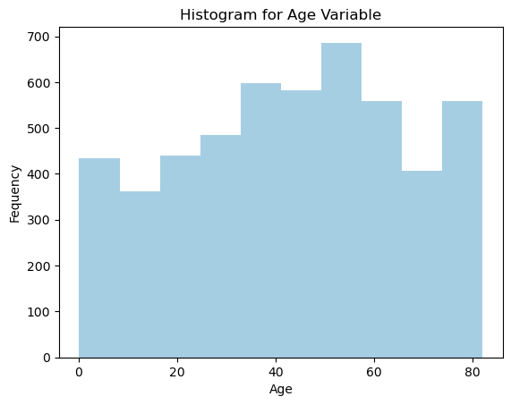

```python
fig = plt.figure()
plt.xlabel("Age")
plt.ylabel("Fequency")
plt.title("Histogram for Age Variable")
plt.hist(data["age"], color= "#a6cee3")
```

The histogram of age we can see has a fairly uniform distribution with a wide range of babies age 0 to elderly individuals over 80. There is a slight peak around 50-60 but this data set includes at least ~350 people from each age bucket.

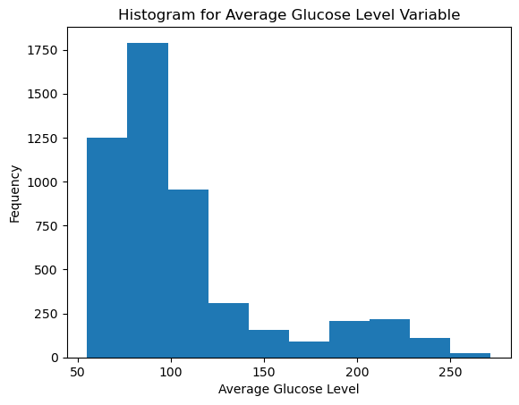

```python
fig = plt.figure()
plt.xlabel("Average Glucose Level")
plt.ylabel("Fequency")
plt.title("Histogram for Average Glucose Level Variable")
plt.hist(data["avg_glucose_level"], color= "#1f78b4")
```

The histogram of average glucose level we can see has a right skew. This is expected because at higher levels this is considered hyperglycemia and likely the person has diabetes.

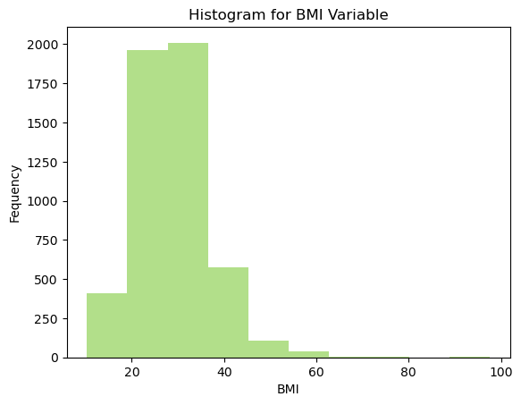

```python
fig = plt.figure()
plt.xlabel("BMI")
plt.ylabel("Fequency")
plt.title("Histogram for BMI Variable")
plt.hist(data["bmi"], color= "#b2df8a")
```

The histogram of body mass index (bmi) we can see also has a right skew. This is expected because at higher levels individuals are considered overweight and obese.

```
<BarContainer object of 3 artists>
```

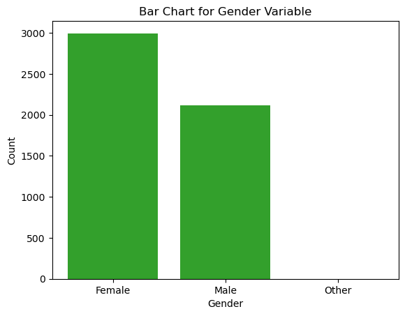

```python
fig = plt.figure()
plt.xlabel("Gender")
plt.ylabel("Count")
plt.title("Bar Chart for Gender Variable")
plt.bar(['Female','Male', 'Other'], data['gender'].value_counts(), color = "#33a02c")
```

From the bar plot of gender there is more females in this dataset than males. There are still over 2000 males in the dataset so I do not forsee this creating an imbalance towards females in the results.

```
<BarContainer object of 2 artists>
```

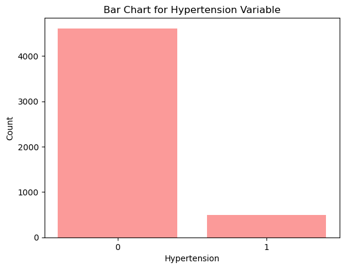

```python
fig = plt.figure()
plt.xlabel("Hypertension")
plt.ylabel("Count")
plt.title("Bar Chart for Hypertension Variable")
plt.bar(['0','1'], data['hypertension'].value_counts(), color = "#fb9a99")
```

The bar chart of hypertension there were very few individuals with this disease and majority of people did not have hypertension.

```
<BarContainer object of 2 artists>
```

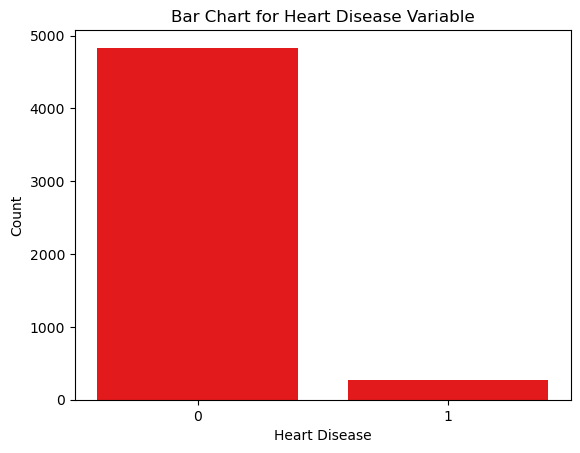

```python
fig = plt.figure()
plt.xlabel("Heart Disease")
plt.ylabel("Count")
plt.title("Bar Chart for Heart Disease Variable")
plt.bar(['0','1'], data['heart_disease'].value_counts(), color = "#e31a1c")
```

The bar chart for heart disease is very similar to hypertension with a large majority of the individuals not having heart disease.

```
<BarContainer object of 2 artists>
```

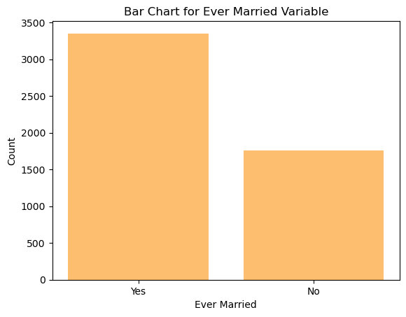

```python
fig = plt.figure()
plt.xlabel("Ever Married")
plt.ylabel("Count")
plt.title("Bar Chart for Ever Married Variable")
plt.bar(['Yes','No'], data['ever_married'].value_counts(), color = "#fdbf6f")
```

The bar chart of married status shows a majority of people have been married or are currently married.

```
<BarContainer object of 5 artists>
```

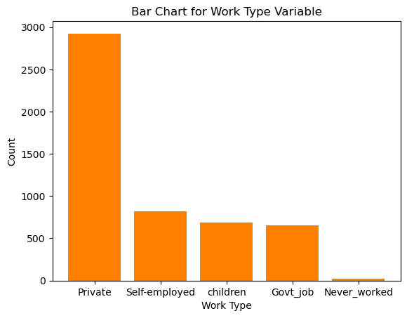

```python
fig = plt.figure()
plt.xlabel("Work Type")
plt.ylabel("Count")
plt.title("Bar Chart for Work Type Variable")
plt.bar(['Private','Self-employed', 'children', 'Govt_job','Never_worked'], data['work_type'].value_counts(), color = "#ff7f00")
```

```
<BarContainer object of 2 artists>
```

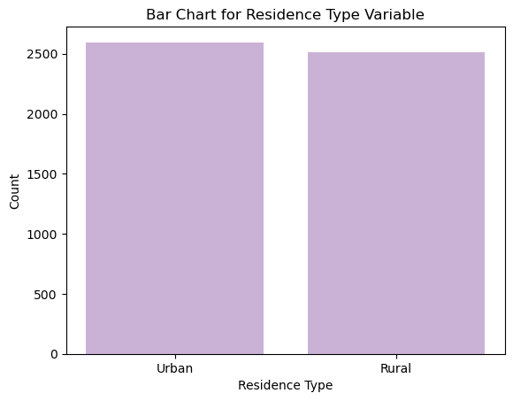

```python
fig = plt.figure()
plt.xlabel("Residence Type")
plt.ylabel("Count")
plt.title("Bar Chart for Residence Type Variable")
plt.bar(['Urban','Rural'], data['Residence_type'].value_counts(), color = "#cab2d6")
```

```
<BarContainer object of 4 artists>
```

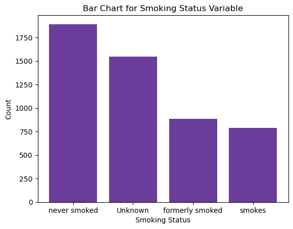

```python
fig = plt.figure()
plt.xlabel("Smoking Status")
plt.ylabel("Count")
plt.title("Bar Chart for Smoking Status Variable")
plt.bar(['never smoked','Unknown', 'formerly smoked', 'smokes'], data['smoking_status'].value_counts(), color = "#6a3d9a")
```

```
<BarContainer object of 2 artists>
```

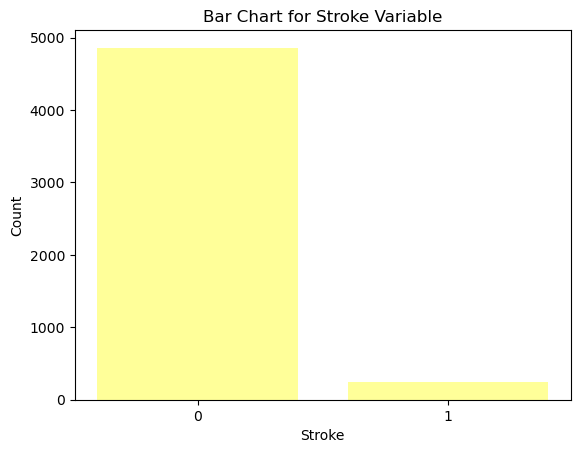

```python
fig = plt.figure()
plt.xlabel("Stroke")
plt.ylabel("Count")
plt.title("Bar Chart for Stroke Variable")
plt.bar(['0','1'], data['stroke'].value_counts(), color = "#ffff99")
```

A large majority of the patients did not ever experience a stroke (value 0).

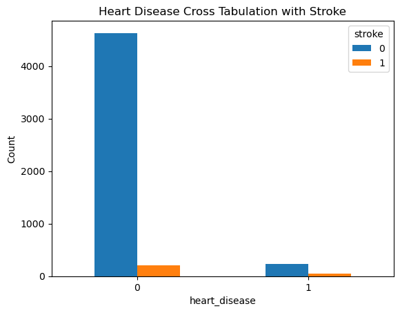

```python
xtab = pd.crosstab(index=data['heart_disease'], columns=data['stroke'])

barplot = xtab.plot.bar(rot=0, title='Heart Disease Cross Tabulation with Stroke', ylabel = "Count")
```

From the cross tabulation of heart disease and stroke we can see in the table below more clearly that a higher percentage of people that had heart disease also had a stroke compared to the people who did not have heart disease.

```python
pd.crosstab(index=data['heart_disease'], columns=data['stroke'], normalize='index').style.format('{:.2%}')
```

| stroke heart_disease | 0 | 1 |
| --- | --- | --- |
| 0 | 95.82% | 4.18% |
| 1 | 82.97% | 17.03% |

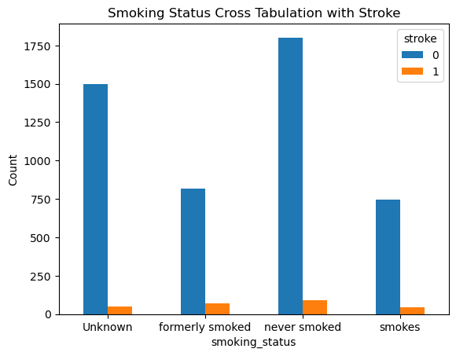

```python
xtab = pd.crosstab(index=data['smoking_status'], columns=data['stroke'])
barplot = xtab.plot.bar(rot=0, title='Smoking Status Cross Tabulation with Stroke', ylabel = "Count")
```

The cross tabulation of smoking status and stroke we do not see clear trends. A slight increase in percentage of people who had formerly smoked and patients who had experienced a stroke. Besides this slight increase all percentages were similar for all categories of smoking status.

```python
pd.crosstab(index=data['smoking_status'], columns=data['stroke'], normalize='index').style.format('{:.2%}')
```

| stroke smoking_status | 0 | 1 |
| --- | --- | --- |
| Unknown | 96.96% | 3.04% |
| formerly smoked | 92.09% | 7.91% |
| never smoked | 95.24% | 4.76% |
| smokes | 94.68% | 5.32% |

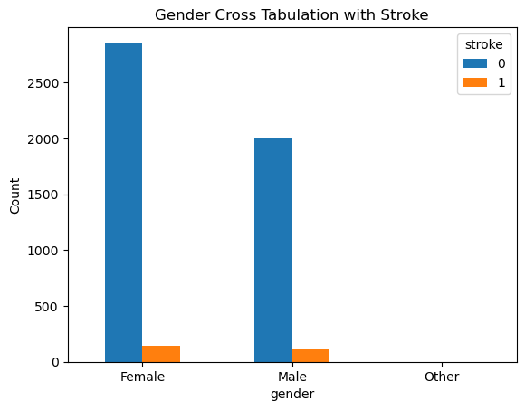

```python
xtab = pd.crosstab(index=data['gender'], columns=data['stroke'])
barplot = xtab.plot.bar(rot=0, title='Gender Cross Tabulation with Stroke', ylabel = "Count")
```

There was a slight increase in males compared to females for patients who experienced a stroke but this difference is very small and could just be considered the variance of the data.

```python
pd.crosstab(index=data['gender'], columns=data['stroke'], normalize='index').style.format('{:.2%}')
```

| stroke gender | 0 | 1 |
| --- | --- | --- |
| Female | 95.29% | 4.71% |
| Male | 94.89% | 5.11% |
| Other | 100.00% | 0.00% |

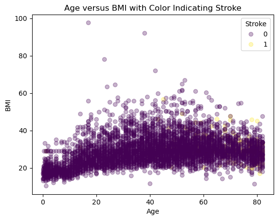

```python
fig, ax = plt.subplots()
plt.xlabel("Age")
plt.ylabel("BMI")
plt.title("Age versus BMI with Color Indicating Stroke")

scatter1 = ax.scatter(data['age'], data['bmi'], c = data['stroke'], alpha = 0.3)
ax.legend(*scatter1.legend_elements(), loc='upper right', title="Stroke")
plt.show()
```

The scatter plot above of age versis BMI with color indicating if the patient experienced a stroke we can see more yellow dots with older people. There is not a clear trend that higher BMI patients have a higher frequency of strokes from this visualization.

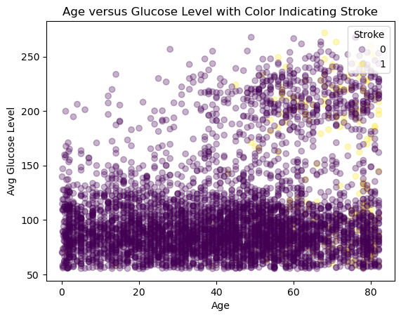

```python
fig, ax = plt.subplots()
plt.xlabel("Age")
plt.ylabel("Avg Glucose Level")
plt.title("Age versus Glucose Level with Color Indicating Stroke")

scatter1 = ax.scatter(data['age'], data['avg_glucose_level'], c = data['stroke'], alpha = 0.3)
ax.legend(*scatter1.legend_elements(), loc='upper right', title="Stroke")
plt.show()
```

The scatter plot above of age and average glucose level there seems to be a trend of higher glucose levels and an increased age see more patients with a stroke. The data is fairly dense at lower glucose levels and even with the transparent dots we could be missing a trend at these lower levels.

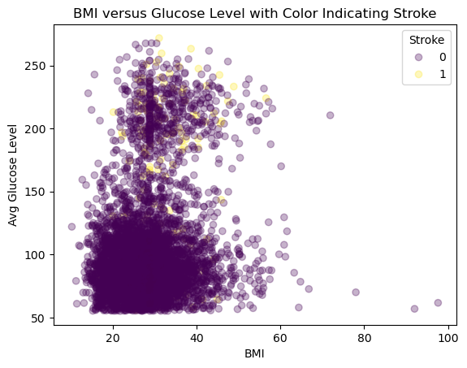

```python
fig, ax = plt.subplots()
plt.xlabel("BMI")
plt.ylabel("Avg Glucose Level")
plt.title("BMI versus Glucose Level with Color Indicating Stroke")

scatter1 = ax.scatter(data['bmi'], data['avg_glucose_level'], c = data['stroke'], alpha = 0.3)
ax.legend(*scatter1.legend_elements(), loc='upper right', title="Stroke")
plt.show()
```

The above plot shows BMI versus average glucose and we can see that elevated glucose levels have more yellow dots or patients with a stroke. Similar to the last plot the data is very dense at lower glucose levels so we could be missing some trends in this visualization.